# Final_Project

Yen Wang and Nathan Frank

5/2/2022

Final Project Yen Wang and Nathan Frank Link to repo: https://github.com/yenwang716/Final-Project

Research Questions: 1. How does minimum wage compare across the United States? 2. Is the minimum wage in the United States keeping up with inflation?

1.US minimum Wage by State from 1968 to 2017 https://www.kaggle.com/datasets/lislejoem/us-minimum-wage-by-state-from-1968-to-2017 This data set lists the minimum wage in every state in the U.S. from 1968 until 2017.

2.U.S. Inflation Rate 1960-2022 https://www.macrotrends.net/countries/USA/united-states/inflation-rate-cpi This website shows the inflation rate in the United States in a similar time period as our first data set.

Cleaning: The firs tdata set includes U.S. territories such as Puerto Rico and the U.S. Virgin Islands which will not be included since we are only looking at states on our maps.

```r
mwd <- read.csv("Minimum Wage Data.csv")
mwd = mwd %>% filter(State != "Puerto Rico")
mwd = mwd %>% filter(State != "U.S. Virgin Islands")
head(mwd)
```

```
##   Year      State State.Minimum.Wage State.Minimum.Wage.2020.Dollars
## 1 1968    Alabama            0.00000                            0.00
## 2 1968     Alaska            2.10000                           15.61
## 3 1968    Arizona            0.46800                            3.48
## 4 1968   Arkansas            0.15625                            1.16
## 5 1968 California            1.65000                           12.26
## 6 1968   Colorado            1.00000                            7.43
##   Federal.Minimum.Wage Federal.Minimum.Wage.2020.Dollars Effective.Minimum.Wage
## 1                 1.15                              8.55                   1.15
## 2                 1.15                              8.55                   2.10
## 3                 1.15                              8.55                   1.15
## 4                 1.15                              8.55                   1.15
## 5                 1.15                              8.55                   1.65
## 6                 1.15                              8.55                   1.15
##   Effective.Minimum.Wage.2020.Dollars CPI.Average
```

[output cut: 34 more lines]

```r
url = "https://www.macrotrends.net/countries/USA/united-states/inflation-rate-cpi"
html <- read_html(url)
tables = html %>% html_table(fill = TRUE)
rl = tables[[2]]
names(rl)[1] = "Year"
names(rl)[2] = "Inflation Rate (%)"
names(rl)[3] = "Annual Change"
rl1 <- rl[-c(1), ]
head(rl1)
```

```
## # A tibble: 6 × 3
##   Year  `Inflation Rate (%)` `Annual Change`
##   <chr> <chr>                <chr>
## 1 2020  1.23%                -0.58%
## 2 2019  1.81%                -0.63%
## 3 2018  2.44%                0.31%
## 4 2017  2.13%                0.87%
## 5 2016  1.26%                1.14%
## 6 2015  0.12%                -1.50%
```

```r
str(mwd)
```

```
## 'data.frame':    2756 obs. of  15 variables:
##  $ Year                                               : int  1968 1968 1968 1968 1968 1968 1968 1968 1968 1968 ...
##  $ State                                              : Factor w/ 54 levels "Alabama","Alaska",..: 1 2 3 4 5 6 7 8 9 10 ...
##  $ State.Minimum.Wage                                 : num  0 2.1 0.468 0.156 1.65 ...
##  $ State.Minimum.Wage.2020.Dollars                    : num  0 15.61 3.48 1.16 12.26 ...
##  $ Federal.Minimum.Wage                               : num  1.15 1.15 1.15 1.15 1.15 1.15 1.15 1.15 1.15 1.15 ...
##  $ Federal.Minimum.Wage.2020.Dollars                  : num  8.55 8.55 8.55 8.55 8.55 8.55 8.55 8.55 8.55 8.55 ...
##  $ Effective.Minimum.Wage                             : num  1.15 2.1 1.15 1.15 1.65 1.15 1.4 1.25 1.25 1.15 ...
##  $ Effective.Minimum.Wage.2020.Dollars                : num  8.55 15.61 8.55 8.55 12.26 ...
##  $ CPI.Average                                        : num  34.8 34.8 34.8 34.8 34.8 34.8 34.8 34.8 34.8 34.8 ...
##  $ Department.Of.Labor.Uncleaned.Data                 : Factor w/ 326 levels "...",".43 - 1.60",..: 1 82 72 30 45 12 35 27 28 1 ...
##  $ Department.Of.Labor.Cleaned.Low.Value              : num  0 2.1 0.468 0.156 1.65 ...
##  $ Department.Of.Labor.Cleaned.Low.Value.2020.Dollars : num  0 15.61 3.48 1.16 12.26 ...
##  $ Department.Of.Labor.Cleaned.High.Value             : num  0 2.1 0.66 0.156 1.65 ...
##  $ Department.Of.Labor.Cleaned.High.Value.2020.Dollars: num  0 15.61 4.91 1.16 12.26 ...
##  $ Footnote                                           : Factor w/ 12 levels "","(b)","(d)",..: 1 1 2 2 2 2 1 1 1 1 ...
```

```r
str(rl1)
```

```
## tibble [61 × 3] (S3: tbl_df/tbl/data.frame)
##  $ Year              : chr [1:61] "2020" "2019" "2018" "2017" ...
##  $ Inflation Rate (%): chr [1:61] "1.23%" "1.81%" "2.44%" "2.13%" ...
##  $ Annual Change     : chr [1:61] "-0.58%" "-0.63%" "0.31%" "0.87%" ...
```

```r
rl2 = rl1 %>% mutate(`Inflation Rate (%)` = parse_number(`Inflation Rate (%)`),
               `Annual Change` = parse_number(`Annual Change`),
               Year = as.factor(Year))
mwd = mwd %>% mutate(Year = as.factor(Year))
```

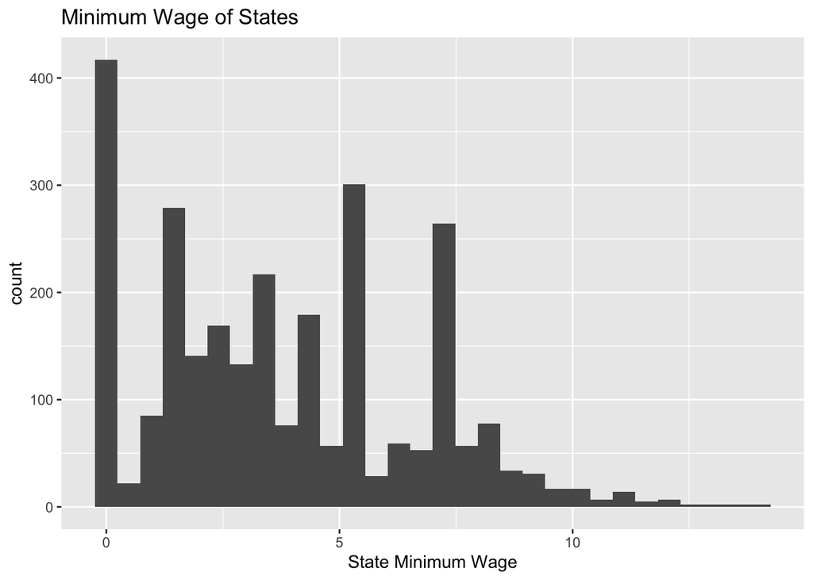

```r
mwd %>% ggplot(aes(x = State.Minimum.Wage)) + geom_histogram() + labs(title="Minimum Wage of States", x="State Minimum Wage")
```

The above histogram shows that from the dataset, there there are more than 400 data entries that reported 0 as the minimum wage and only less than 100 reported a minimum wage greater than 10. Most of them lies between 1.5 to 7 dollars.

## The average minimum wage of every state through out the years

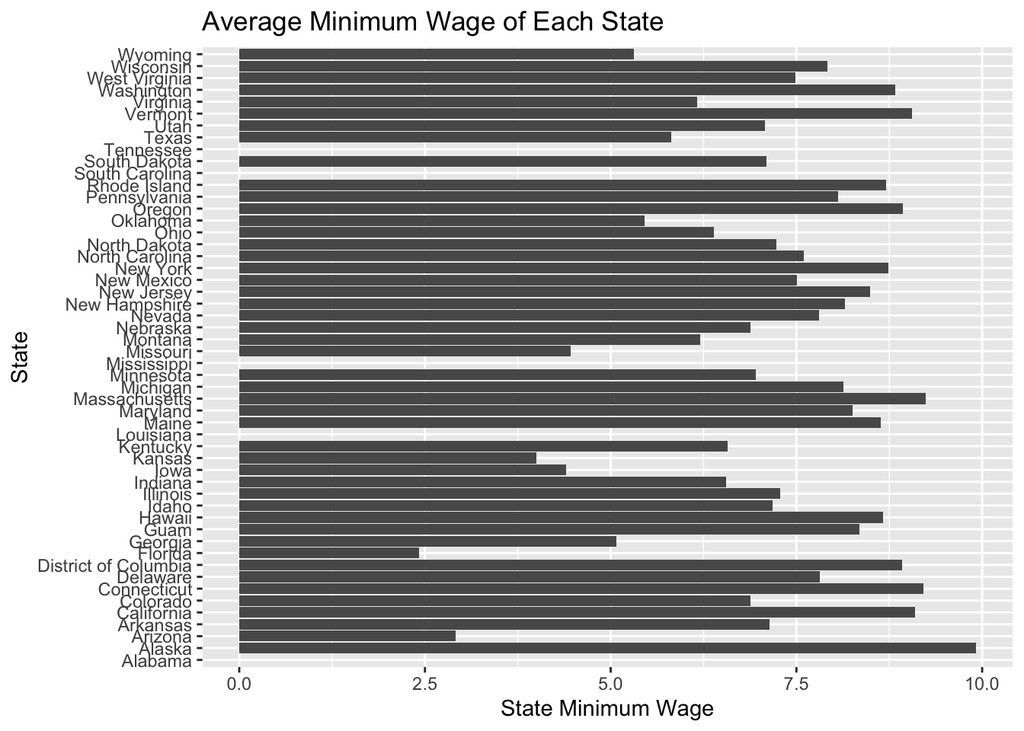

```r
mwd.state = mwd %>% group_by(State) %>%
  summarise(m.state = mean(State.Minimum.Wage.2020.Dollars, na.rm = TRUE)) %>%
  arrange(desc(m.state))

mwd.state %>% ggplot(aes(x = State)) +
  geom_bar(aes(weight = m.state)) +
  coord_flip() +
  ylab("State Minimum Wage") +
  ggtitle("Average Minimum Wage of Each State")
```

The above graph represents the average minimum wage of every state from 1968 to 2020. We can conclude that Alaska has the highest minimum wage and the second highest is Massachusetts. Some reasons are that Massachusetts is one of the thirteen colonies, which means it was developed earlier than some other states, with more jobs and companies.

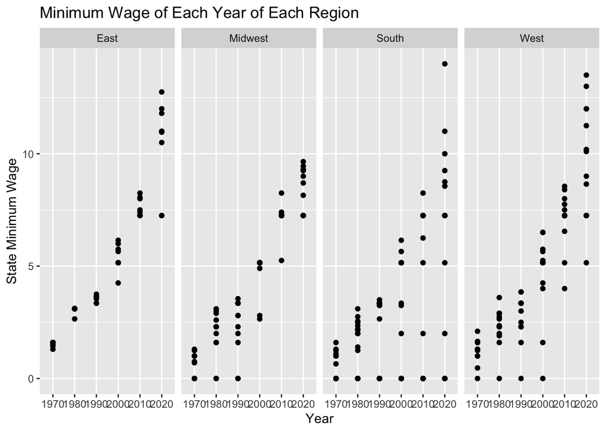

```r
mwd1 = mwd[mwd$Year %in% c(1970, 1980, 1990, 2000, 2010, 2020), ]

mwd.west = mwd1[mwd1$State %in% c("Alaska", "Arizona", "California", "Hawaii", "Idaho", "Montana", "Nevada", "New Mexico", "Oregon", "Utah", "Washington", "Wyoming", "Colorado"), ]
mwd.west$Region = "West"

mwd.east = mwd1[mwd1$State %in% c("Connecticut", "Maine", "Massachusetts", "New Hampshire", "Rhode Island", "Vermont", "New Jersey", "New York", "Pennsylvania"), ]
mwd.east$Region = "East"

mwd.south = mwd1[mwd1$State %in% c("Delaware", "Florida", "Georgia", "Maryland", "North Carolina", "South Carolina", "Virginia", "District of Columbia", "West Virginia", "Alabama", "Kentucky", "Mississippi", "Tennessee", "Arkansas", "Louisiana", "Oklahoma", "Texas"), ]
mwd.south$Region = "South"

mwd.midwest = mwd1[mwd1$State %in% c("Illinois", "Indiana", "Michigan", "Ohio", "Wisconsin", "Iowa", "Kansas", "Minnesota", "Missouri", "Nebraska", "North Dakota", "South Dakota"), ]
mwd.midwest$Region = "Midwest"

mwd2 = rbind(mwd.west, mwd.east, mwd.midwest, mwd.south)

mwd2 = mwd2 %>% mutate(Region = as.factor(Region))

mwd2 %>% ggplot(aes(x = Year, y = State.Minimum.Wage)) +
  geom_point() +
  facet_grid(~Region) +
  ylab("State Minimum Wage") +
  ggtitle("Minimum Wage of Each Year of Each Region ")
```

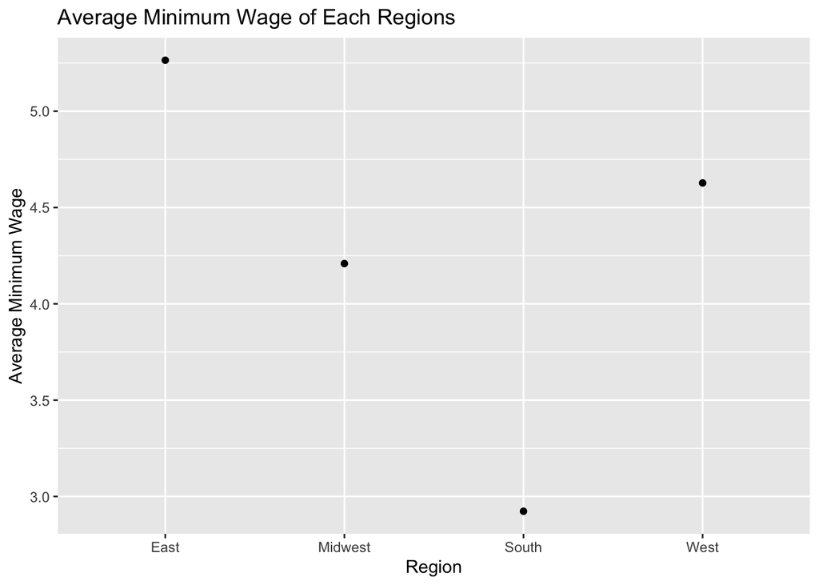

```r
mwd2 %>% group_by(Region) %>% summarise(m.region = mean(State.Minimum.Wage, na.rm = TRUE)) %>%
  ggplot(aes(x = Region, y = m.region)) + geom_point() + ggtitle("Average Minimum Wage of Each Regions") + ylab("Average Minimum Wage")
```

From the above plot, we can conclude that the east has the highest minimum wage on average and the south has the lowest.

## The average minimum wage through out the years

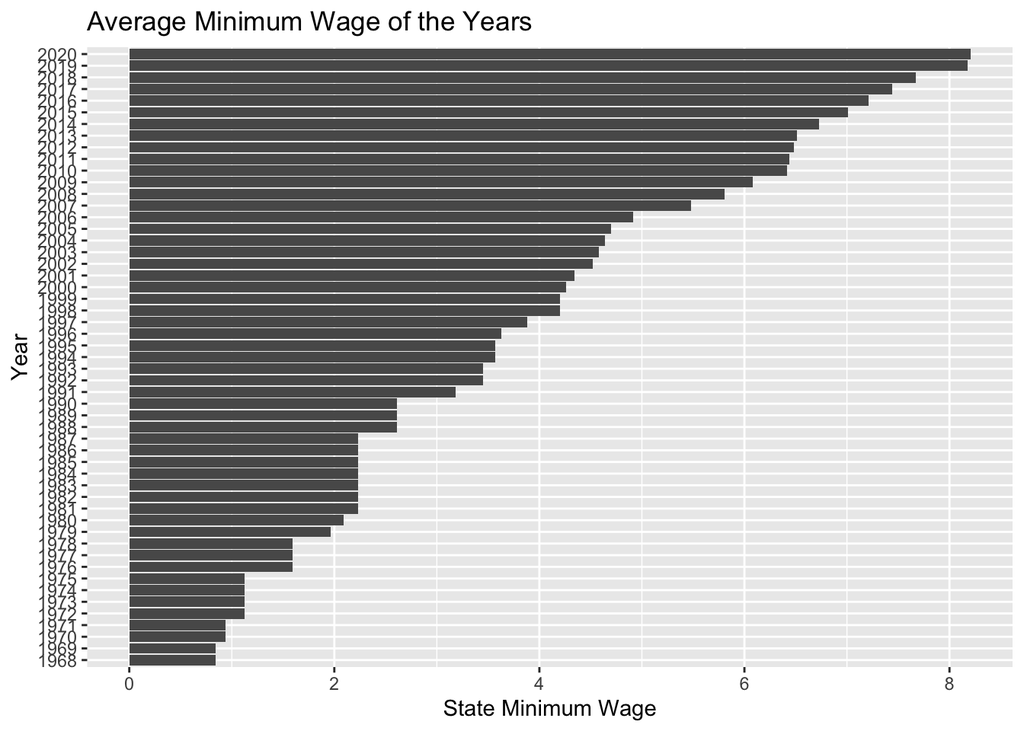

```r
mwd.year = mwd %>% group_by(Year) %>%
  summarise(m.year = mean(State.Minimum.Wage, na.rm = TRUE),
            m.year.2020 = mean(State.Minimum.Wage.2020.Dollars, na.rm = TRUE))

mwd.year %>% ggplot(aes(x = Year)) +
  geom_bar(aes(weight = m.year)) +
  coord_flip() +
  ylab("State Minimum Wage") +
  ggtitle("Average Minimum Wage of the Years")
```

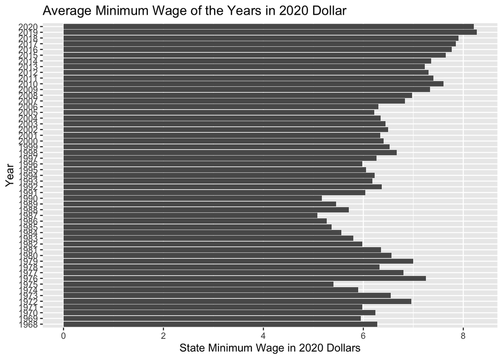

```r
mwd.year %>% ggplot(aes(x = Year)) +
  geom_bar(aes(weight = m.year.2020)) +
  coord_flip() +
  ylab("State Minimum Wage in 2020 Dollars") +
  ggtitle("Average Minimum Wage of the Years in 2020 Dollar")
```

From the above plots show how the minimum wage of the country has increased through out the years. The first bar plot shows that before 1980, the average minimum wage was less than 2 dollars, and as the years come by, the minimum wage has increased to 6 dollars in 2009. On the other hand, the second plot shows the average minimum wage in 2020 dollars, which is not a linear line. We can conclude that the average minimum wage of the US has increased almost every year, but as the years come by, the value of US dollars has changed as well.

## Effective Minimum Wage

The effective minimum wage variable is the minimum wage that it enforced in each state. This number is equal to the maximum between a state’s minimum wage and the federal minimum wage. The following box-plots show that the median wage is close to the feral wage until in each year except 2020. All outliers on the plots are caused by a higher effective minimum wage than the upper whisker. The median wage is close to the federal minimum wage because any state that has a wage lower must use the federal minimum wage. This pattern does not continue into 2020 because the median value is over a dollar more than the federal minimum wage.

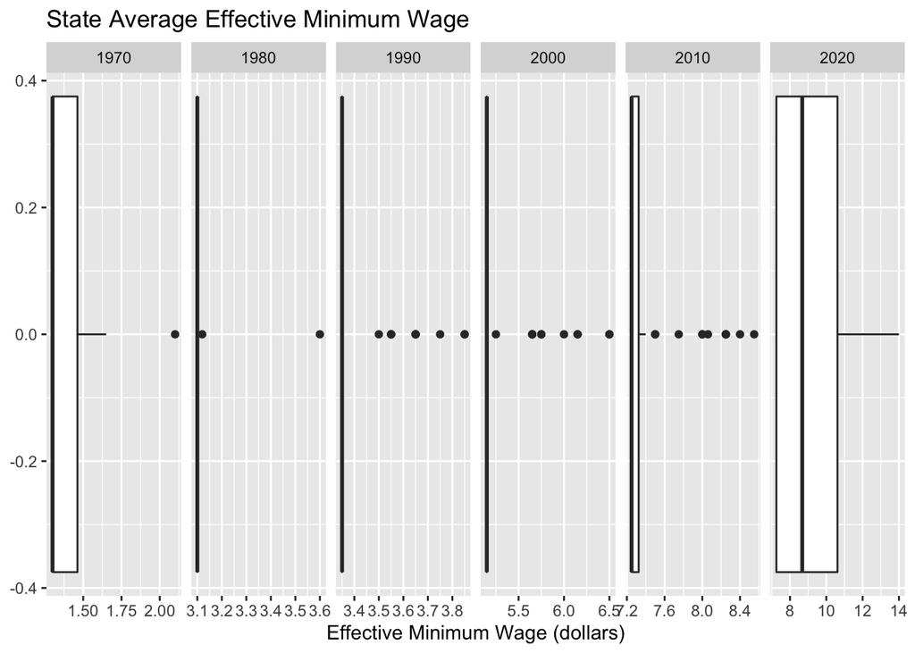

```r
mwd %>% filter(Year %in% c(1970, 1980, 1990, 2000, 2010, 2020)) %>% ggplot(aes(x=Effective.Minimum.Wage)) + geom_boxplot() + facet_grid(~Year, scales = "free") +
  labs(title="State Average Effective Minimum Wage", x="Effective Minimum Wage (dollars)")
```

## Maps

Here are maps that look at the effective minimum wage in 1968 and 2020. The map of 1968 has many more states with effective minimum wages equal to the federal minimum wage compared to 2020. In 1968, the states with the highest minimum wage were on the east and west coast. This is also true in 2020, and it is most likely because they are states with large cities that have higher costs of living.

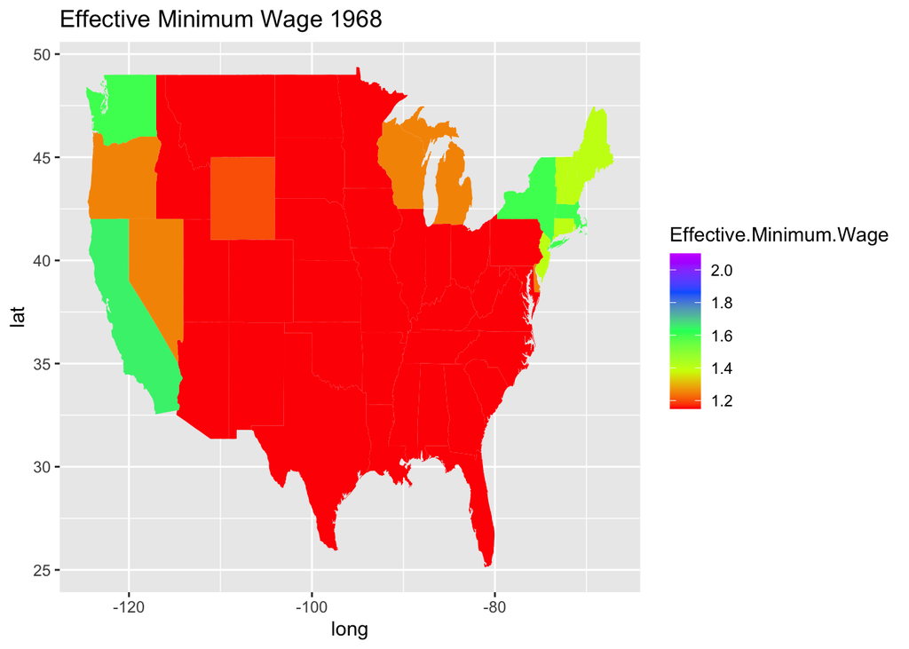

```r
states <- map_data("state")

mwd2 = mwd
mwd2$region = tolower(mwd2$State)

mwd2 = mwd2 %>% filter(State != "hawaii", State != "alaska")

mwd.map2020 = mwd2 %>% filter(Year == 2020) %>% left_join(states, by="region")

mwd.map1968 = mwd2 %>% filter(Year == 1968) %>% left_join(states, by="region")

mwd.map1968 %>%
  ggplot(aes(x = long, y = lat, fill=Effective.Minimum.Wage)) +
  geom_polygon(aes(group=group)) + scale_fill_gradientn(colors=rainbow(5)) +
  labs(title="Effective Minimum Wage 1968")
```

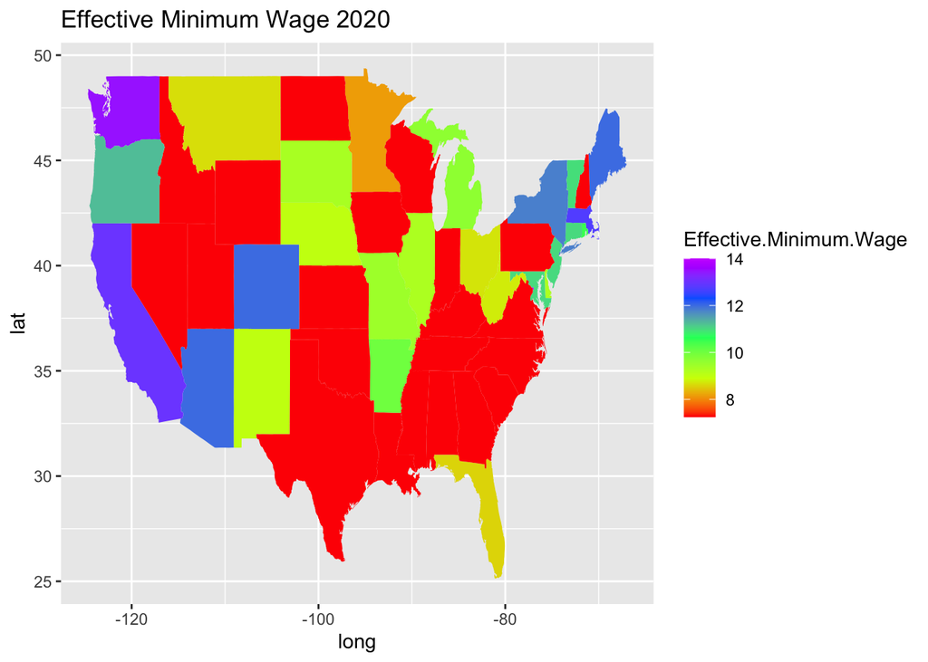

```r
mwd.map2020 %>%
  ggplot(aes(x = long, y = lat, fill=Effective.Minimum.Wage)) +
  geom_polygon(aes(group=group)) + scale_fill_gradientn(colors=rainbow(5)) +
  labs(title="Effective Minimum Wage 2020")
```

## Minimum Wage compared to inflation

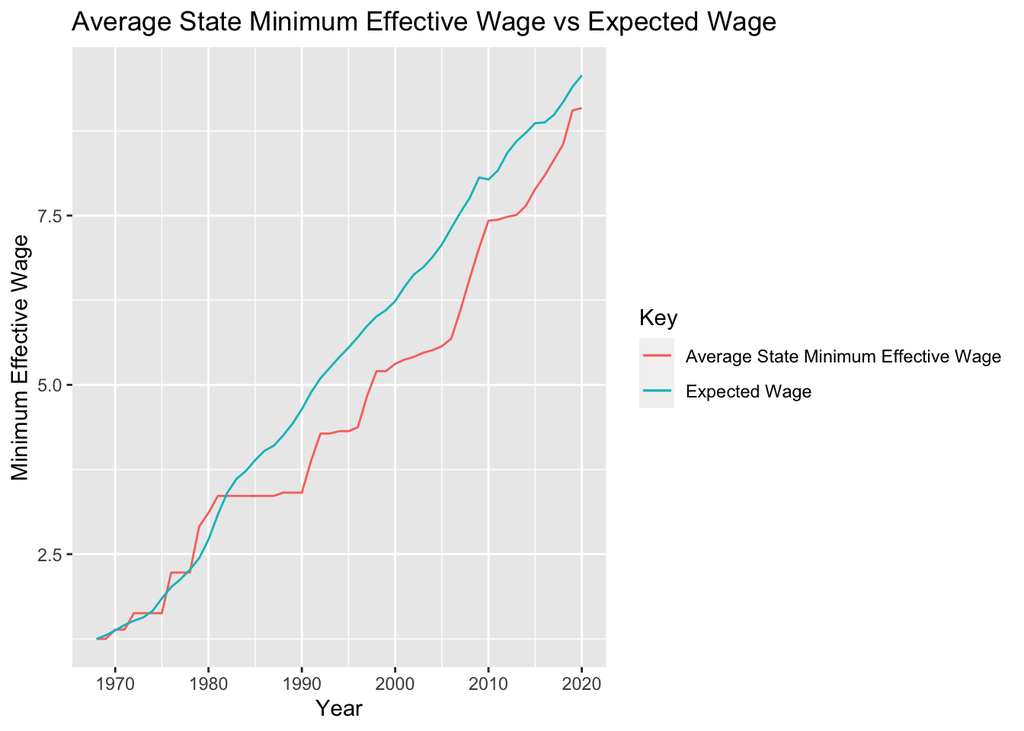

```r
mwd.year = mwd %>% group_by(Year) %>%
  summarise(m.wage = mean(Effective.Minimum.Wage, na.rm = TRUE), fed.wage = mean(Federal.Minimum.Wage, na.rm= TRUE))

rl3 = rl2 %>% filter(as.integer(as.character(Year)) > 1967)
rl3$Year = as.integer(as.character(rl3$Year))
mwd.year$Year = as.integer(as.character(mwd.year$Year))
wage.with.inflation = mwd.year %>% left_join(rl3, by="Year")

wage.with.inflation$ExpectedWage = wage.with.inflation$m.wage[1]

for (x in 2:53) {
  wage.with.inflation$ExpectedWage[x] = wage.with.inflation$ExpectedWage[x-1] * (1 + wage.with.inflation$`Inflation Rate (%)`[x-1] / 100)
}


ggplot(wage.with.inflation, aes(x=Year, group=1)) +
  geom_line(aes(y = m.wage, colour = "Average State Minimum Effective Wage")) +
  geom_line(aes(y = ExpectedWage, color = "Expected Wage")) +
  labs(title="Average State Minimum Effective Wage vs Expected Wage", y="Minimum Effective Wage", color="Key")
```

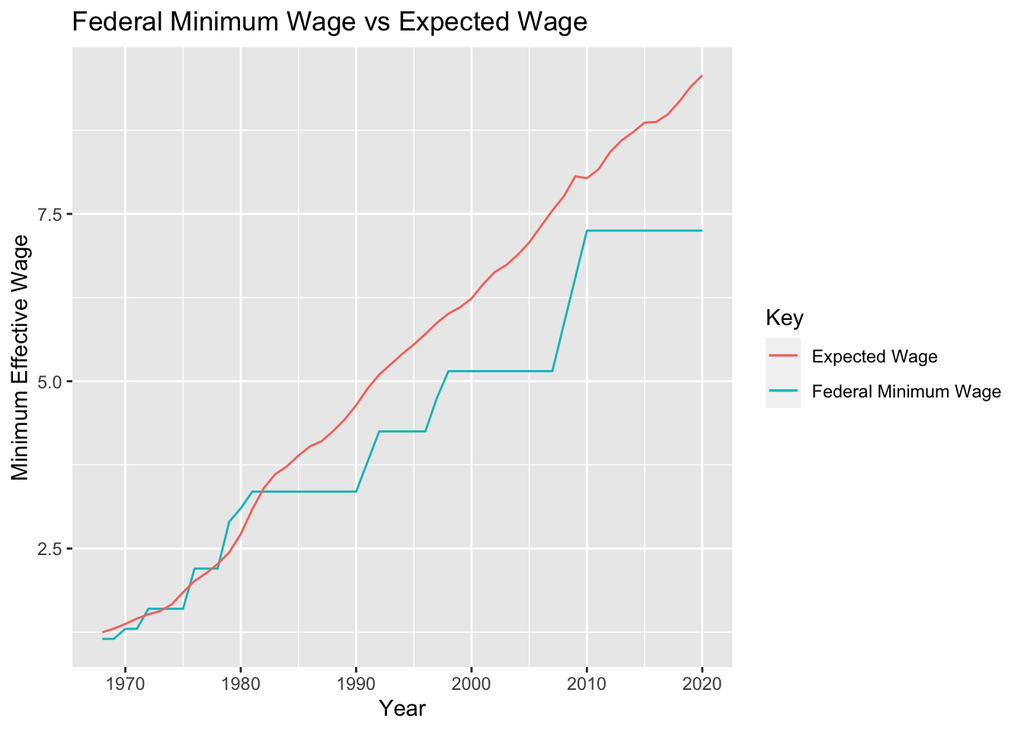

```r
ggplot(wage.with.inflation, aes(x=Year, group=1)) +
  geom_line(aes(y = fed.wage, colour = "Federal Minimum Wage")) +
  geom_line(aes(y = ExpectedWage, color = "Expected Wage")) +
  labs(title="Federal Minimum Wage vs Expected Wage", y="Minimum Effective Wage", color="Key")
```